# Analisi sul Dataset dei Pokemon

Massimiliano Baldo

25/8/2020

# Introduzione

I Pokemon sono delle creature immaginarie che vivono a stretto contatto con gli umani.  
Alcune volte sono impiegati nei lavori pubblici, altri nei concorsi e infine, l’ambito che interessa a noi, quello delle lotte.  
Le informazioni importanti da sapere sui pokemon sono le seguenti:

- Ogni pokemon ha delle stastiche base (chiamate “stats”) e includono:
  - HP = Punti Salute
  - ATK = Punti Attacco Fisico
  - DEF = Punti Difesa Fisica
  - SP_ATK = Punti Attacco Speciale
  - SP_DEF = Punti Difesa Speciale
  - SPD = Punti Velocità
- Ogni pokemon ha almeno un tipo (ovvero un elemento naturale), altri ne hanno 2.
- Ogni pokemon ha un livello che varia da 1 a 100 (estremi inclusi). Più un pokemon sale di livello, più le sue statistiche base aumentano.
- Alcuni pokemon posso evolversi: tale processo consiste nel cambio di aspetto, di dimensione, di tipo appartenente e di stats.

Prima di iniziare a parlare dell’analisi, è necessario fare alcune premesse per poter comprendere il codice scritto:

- Nel set denominato “aux_set” sono presenti i moltiplicatori di danni in base alla mossa subita e al tipo del pokemon difensore, questi dati eran necessari per la maggior parte delle domande di queste analisi.
- Nel set denominato “set” sono presenti pokemon alcuni pokemon che nel primo set non ci sono, pertanto per coerenza di dati, il set è filtrato fino alle generazioni presenti anche nell’aux_set.
- Nel dataset “set” non ci sono dati mancanti come nel primo, questo perchè le forme speciali di alcuni pokemon vengono gestite in maniera molto più ottimale (per questo motivo ci sono più pokemon rispetto al primo set).

## Obiettivo

L’obiettivo di questa analisi è rispondere a delle domande che sono state mosse dalla mia curiosità sin da giovane.  
Tali domande sono le seguenti:

- Qual è il tipo più forte nel complesso? Qual è il più debole?
- Qual è il doppio tipo esistente nel complesso il più forte? Qual è il più debole?
- Qual è il tipo più probabile che sia un Pokemon leggendario?
- Come si correla l’altezza e il peso di un Pokemon con le sue varie statistiche di base?
- Si può costruire un dream team Pokemon?  
  Una squadra di 6 Pokemon che rimane relativamente impenetrabile a qualsiasi altra squadra di 6 Pokemon.

## Nota personale

Sin da quando ero ragazzino i pokemon sono sempre stati una ammirazione per me, ho capito solo qualche anno fa qual fosse il vero potenziale di un pokemon e le possibili opportunità che il gioco stesso ti proponeva.  
Spero che questa analisi possa far anche voi scoprire qualcosa in più di questo mondo immenso.

## Prima Domanda: Qual è il tipo più forte nel complesso? Qual è il più debole?

### Creazione della Weak Table

Abbiamo a disposizione i moltiplicatori di danni degli attachi sui pokemon, possiamo determinare quanto danno potrebbe ricevere un determinato tipo di pokemon se ricevesse un attacco di ogni tipo.

Possiamo far ciò filtrando tutti i pokemon che hanno un solo tipo, eliminare tutti i doppioni così da avere una tabella che mostra le varie debolezze dei singoli tipi pokemon

```r
weak_table <- aux_set %>%
  select(type1, type2, contains("against")) %>%
  filter(type2 == "") %>%
  distinct() %>% ## make only one type for row because are identicaly
  select(-type2) %>%
  rename(type = type1)
```

| type | against_bug | against_dark | against_dragon | against_electric | against_fairy | against_fight | against_fire | against_flying | against_ghost | against_grass | against_ground | against_ice | against_normal | against_poison | against_psychic | against_rock | against_steel | against_water |
| --- | --- | --- | --- | --- | --- | --- | --- | --- | --- | --- | --- | --- | --- | --- | --- | --- | --- | --- |
| fire | 0.5 | 1.0 | 1.0 | 1.0 | 0.5 | 1.0 | 0.5 | 1.0 | 1.0 | 0.5 | 2.0 | 0.5 | 1.0 | 1.0 | 1.0 | 2.0 | 0.5 | 2.0 |
| water | 1.0 | 1.0 | 1.0 | 2.0 | 1.0 | 1.0 | 0.5 | 1.0 | 1.0 | 2.0 | 1.0 | 0.5 | 1.0 | 1.0 | 1.0 | 1.0 | 0.5 | 0.5 |
| bug | 1.0 | 1.0 | 1.0 | 1.0 | 1.0 | 0.5 | 2.0 | 2.0 | 1.0 | 0.5 | 0.5 | 1.0 | 1.0 | 1.0 | 1.0 | 2.0 | 1.0 | 1.0 |
| poison | 0.5 | 1.0 | 1.0 | 1.0 | 0.5 | 0.5 | 1.0 | 1.0 | 1.0 | 0.5 | 2.0 | 1.0 | 1.0 | 0.5 | 2.0 | 1.0 | 1.0 | 1.0 |
| electric | 1.0 | 1.0 | 1.0 | 0.5 | 1.0 | 1.0 | 1.0 | 0.5 | 1.0 | 1.0 | 2.0 | 1.0 | 1.0 | 1.0 | 1.0 | 1.0 | 0.5 | 1.0 |
| fairy | 0.5 | 0.5 | 0.0 | 1.0 | 1.0 | 0.5 | 1.0 | 1.0 | 1.0 | 1.0 | 1.0 | 1.0 | 1.0 | 2.0 | 1.0 | 1.0 | 2.0 | 1.0 |
| fighting | 0.5 | 0.5 | 1.0 | 1.0 | 2.0 | 1.0 | 1.0 | 2.0 | 1.0 | 1.0 | 1.0 | 1.0 | 1.0 | 1.0 | 2.0 | 0.5 | 1.0 | 1.0 |
| psychic | 2.0 | 2.0 | 1.0 | 1.0 | 1.0 | 0.5 | 1.0 | 1.0 | 2.0 | 1.0 | 1.0 | 1.0 | 1.0 | 1.0 | 0.5 | 1.0 | 1.0 | 1.0 |
| ground | 1.0 | 1.0 | 1.0 | 0.0 | 1.0 | 1.0 | 1.0 | 1.0 | 1.0 | 2.0 | 1.0 | 2.0 | 1.0 | 0.5 | 1.0 | 0.5 | 1.0 | 2.0 |
| normal | 1.0 | 1.0 | 1.0 | 1.0 | 1.0 | 2.0 | 1.0 | 1.0 | 0.0 | 1.0 | 1.0 | 1.0 | 1.0 | 1.0 | 1.0 | 1.0 | 1.0 | 1.0 |

[output cut: 8 more lines]

### Somma dei Punti

Ora sommiamo i diversi danni possibili che può ricevere un tipo e riordiniamoli

| Type | Weak Point |
| --- | --- |
| steel | 15.0 |
| ghost | 17.0 |
| poison | 17.5 |
| electric | 17.5 |
| fairy | 17.5 |
| fire | 18.0 |
| water | 18.0 |
| normal | 18.0 |
| flying | 18.5 |
| ground | 19.0 |

[output cut: 8 more lines]

Prendiamo il considerazione il primo della tabella (quello con meno punti) e l’ultimo (quello con più punti).

|  | Type | Weak Point |
| --- | --- | --- |
| 1 | steel | 15 |

|  | Type | Weak Point |
| --- | --- | --- |
| 18 | ice | 21.5 |

Otteniamo che il tipo con un numero di danni è il ferro, mentre il pokemon con maggiori punti di danni che può subire è quello di tipo ghiaccio.

## Seconda Domanda: Qual è il doppio tipo esistente nel complesso il più forte? Qual è il più debole?

Visto che i pokemon di rado hanno solo una tipologia di tipo, è interessante capire quale accoppiata di tipi sia quella che può ricevere meno danno e quella più vulnerabile

### Creazione della Double Weak Table

Come prima, creiamo una seconda la tabelle delle debolezze considerando ora anche il secondo tipo dei pokemon

```r
double_weak_table <- aux_set %>%
  select(type1, type2, contains("against")) %>%
  filter(type2 != "") %>%
  distinct()
```

| type1 | type2 | against_bug | against_dark | against_dragon | against_electric | against_fairy | against_fight | against_fire | against_flying | against_ghost | against_grass | against_ground | against_ice | against_normal | against_poison | against_psychic | against_rock | against_steel | against_water |
| --- | --- | --- | --- | --- | --- | --- | --- | --- | --- | --- | --- | --- | --- | --- | --- | --- | --- | --- | --- |
| grass | poison | 1.00 | 1.00 | 1.0 | 0.50 | 0.50 | 0.50 | 2.00 | 2.00 | 1.0 | 0.25 | 1.00 | 2.00 | 1.00 | 1.00 | 2.00 | 1.00 | 1.00 | 0.50 |
| fire | flying | 0.25 | 1.00 | 1.0 | 2.00 | 0.50 | 0.50 | 0.50 | 1.00 | 1.0 | 0.25 | 0.00 | 1.00 | 1.00 | 1.00 | 1.00 | 4.00 | 0.50 | 2.00 |
| bug | flying | 0.50 | 1.00 | 1.0 | 2.00 | 1.00 | 0.25 | 2.00 | 2.00 | 1.0 | 0.25 | 0.00 | 2.00 | 1.00 | 1.00 | 1.00 | 4.00 | 1.00 | 1.00 |
| bug | poison | 0.50 | 1.00 | 1.0 | 1.00 | 0.50 | 0.25 | 2.00 | 2.00 | 1.0 | 0.25 | 1.00 | 1.00 | 1.00 | 0.50 | 2.00 | 2.00 | 1.00 | 1.00 |
| normal | flying | 0.50 | 1.00 | 1.0 | 2.00 | 1.00 | 1.00 | 1.00 | 1.00 | 0.0 | 0.50 | 0.00 | 2.00 | 1.00 | 1.00 | 1.00 | 2.00 | 1.00 | 1.00 |
| normal | dark | 1.00 | 1.00 | 1.0 | 1.00 | 1.00 | 2.00 | 1.00 | 1.00 | 0.0 | 1.00 | 1.00 | 1.00 | 1.00 | 1.00 | 1.00 | 1.00 | 1.00 | 1.00 |
| electric | electric | 1.00 | 1.00 | 1.0 | 0.50 | 1.00 | 1.00 | 1.00 | 0.50 | 1.0 | 1.00 | 2.00 | 1.00 | 1.00 | 1.00 | 1.00 | 1.00 | 0.50 | 1.00 |
| ground | ice | 1.00 | 1.00 | 1.0 | 0.00 | 1.00 | 1.00 | 1.00 | 1.00 | 1.0 | 2.00 | 1.00 | 2.00 | 1.00 | 0.50 | 1.00 | 0.50 | 1.00 | 2.00 |
| poison | ground | 0.50 | 1.00 | 1.0 | 0.00 | 0.50 | 0.50 | 1.00 | 1.00 | 1.0 | 1.00 | 2.00 | 2.00 | 1.00 | 0.25 | 2.00 | 0.50 | 1.00 | 2.00 |
| fire | ice | 0.50 | 1.00 | 1.0 | 1.00 | 0.50 | 1.00 | 0.50 | 1.00 | 1.0 | 0.50 | 2.00 | 0.50 | 1.00 | 1.00 | 1.00 | 2.00 | 0.50 | 2.00 |

[output cut: 138 more lines]

### Somma dei Punti

Rieseguiamo le stesse operazioni di prima per conteggiare i danni e riordinarli

```r
sum <- double_weak_table %>%
  select(-contains("type")) %>%
  rowSums()

double_weak_table <- double_weak_table %>%
  select(-contains("against")) %>%
  mutate(sum = sum) %>%
  arrange(sum) %>%
  rename(
    "Type 1" = type1,
    "Type 2" = type2,
    "Weak Point" = sum
  )
```

Osserviamo la prima parte della tabella

|  | Type 1 | Type 2 | Weak Point |
| --- | --- | --- | --- |
| 1 | steel | fairy | 13.25 |
| 2 | steel | flying | 13.50 |
| 3 | steel | dragon | 14.25 |
| 4 | steel | ghost | 14.25 |
| 5 | water | steel | 14.50 |
| 6 | dark | ghost | 15.50 |

E adesso l’ultima

|  | Type 1 | Type 2 | Weak Point |
| --- | --- | --- | --- |
| 1 | rock | ice | 26.00 |
| 2 | bug | grass | 25.00 |
| 3 | grass | ice | 25.00 |
| 4 | rock | ground | 24.25 |
| 5 | ground | rock | 24.25 |
| 6 | grass | psychic | 24.00 |

L’accoppiata con meno danni che può subire è Ferro-Fata (sarà importante da ricordare) mentre quella più debole è Roccia-Ghiaccio.  
Ahimè, avere un pokemon come Auorus in squadra è molto svantaggioso.

## Terza Domanda: Qual è il tipo più probabile che sia un Pokemon leggendario?

Da parte della community c’è sempre stata una enorme ammirazione per i pokemon leggendari a tal punto che molti giocatori sceglievano una versione del gioco piuttosto che un’altra solo per avere quel pokemon leggendario.

Cerchiamo allora di capire quale siano i più frequenti tipi di pokemon leggendari e di ipotizzare se in una prossima uscita di un gioco pokemon ci sarà un pokemon con i tipi individuati.

### Ricerca dei pokemon leggendari

```r
legendary <- set %>%
  select(NAME, TYPE1, TYPE2, LEGENDARY) %>%
  filter(LEGENDARY == TRUE) %>%
  distinct() ## necessario poichè alucni pokemon come Deoxsy cambiano forma ma non tipo
```

| NAME | TYPE1 | TYPE2 | LEGENDARY |
| --- | --- | --- | --- |
| Articuno | Ice | Flying | 1 |
| Zapdos | Electric | Flying | 1 |
| Moltres | Fire | Flying | 1 |
| Mewtwo | Psychic |  | 1 |
| Mega Mewtwo X | Psychic | Fighting | 1 |
| Mega Mewtwo Y | Psychic |  | 1 |
| Mew | Psychic |  | 1 |
| Raikou | Electric |  | 1 |
| Entei | Fire |  | 1 |
| Suicune | Water |  | 1 |

[output cut: 86 more lines]

### Trovare il Tipo che risulta più frequente

```r
t1 <- as.data.frame(table(legendary$TYPE1))
t2 <- as.data.frame(table(legendary$TYPE2, exclude = ""))

# Il full join serve perchè si ha due tabelle distinte e vogliamo vedere i valori accoppiati,
# così da poterli sommare
legendary_type_sum <- full_join(t1, t2, by = "Var1") %>%
  select(-Var1) %>%
  rowSums()

t1 %>%
  rename(Type = Var1) %>%
  select(-Freq) %>%
  mutate(Freq = legendary_type_sum) %>%
  arrange(-Freq)
```

| Type | Freq |
| --- | --- |
| Psychic | 29 |
| Dragon | 16 |
| Steel | 14 |
| Flying | 13 |
| Water | 10 |
| Fighting | 9 |
| Fire | 9 |
| Fairy | 8 |
| Electric | 7 |
| Ghost | 6 |

[output cut: 8 more lines]

Abbiamo trovato che i tipi più frequenti tra i pokemon leggendari sono il tipo Psico e quello Drago.

## Quarta Domanda: Come si correla l’altezza e il peso di un Pokemon con le sue varie statistiche di base?

Un’ aspetto importante dei pokemon è l’evoluzione, non solo cambia l’aspetto fisico ma ne aumenta anche le statistiche di lotta.  
Effettivamente, esiste una sorta di correlazione tra l’aumento di peso e di altezza con gli stats?

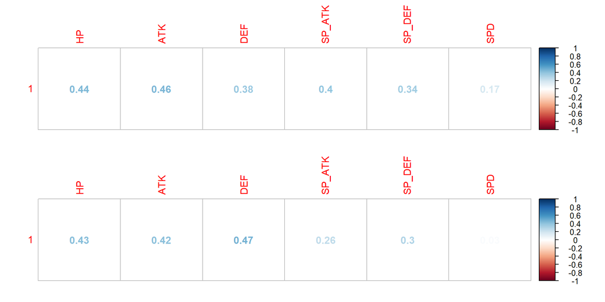

```r
par(mfrow=c(2,1))
# Correlazione tra altezza e gli stati
corrplot(cor(set$HEIGHT, set[, c(16:21)]),
  method = "number",
  type = "upper", # show only upper side
)
# Correlazione tra peso e gli stati
corrplot(cor(set$WEIGHT, set[, c(16:21)]),
  method = "number",
  type = "upper",
)
```

Proviamo a verificare se magari esiste una correlazione di tipo quadratica.

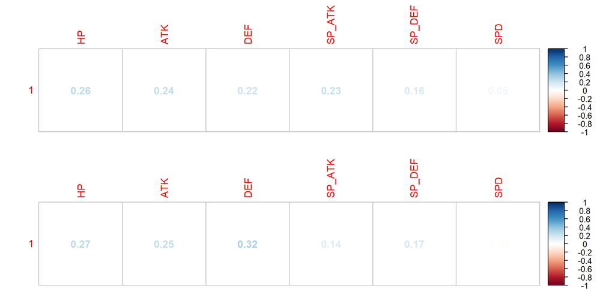

```r
# Creiamo i quadrati delle altezze e dei pesi e valutiamo se esiste una correlazione lineare tra gli stats
quad_height <- set[, c(14)] ^ 2
quad_weight <- set[, c(15)] ^ 2

par(mfrow=c(2,1))

corrplot(cor(quad_height, set[, c(16:21)]),
  method = "number",
  type = "upper"
)

corrplot(cor(quad_weight, set[, c(16:21)]),
  method = "number",
  type = "upper"
)
```

Anche con una correlazione quadratica abbiamo dei valori molto più piccoli (vicini al 0.2), pertanto non esiste effettivamente una correlazione quadratica.

Utlima osservazione, proviamo con una funzione logaritmica

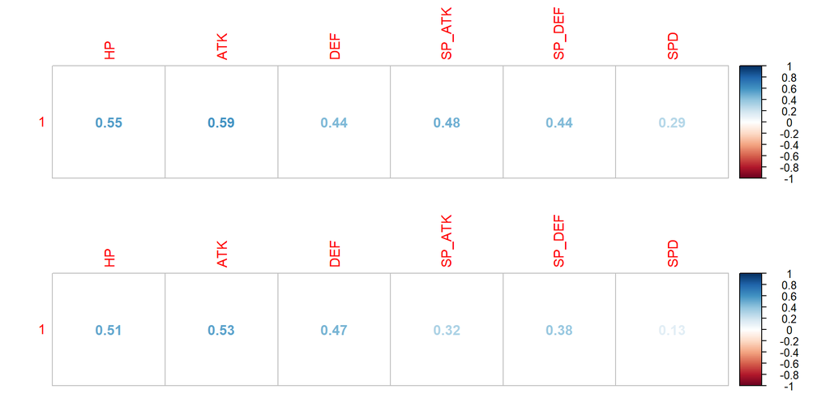

```r
log_height <- set[, c(14)] %>% log()
log_weight <- set[, c(15)] %>% log()

par(mfrow=c(2,1))
corrplot(cor(log_height, set[, c(16:21)]),
  method = "number",
  type = "upper"
)
corrplot(cor(log_weight, set[, c(16:21)]),
  method = "number",
  type = "upper"
)
```

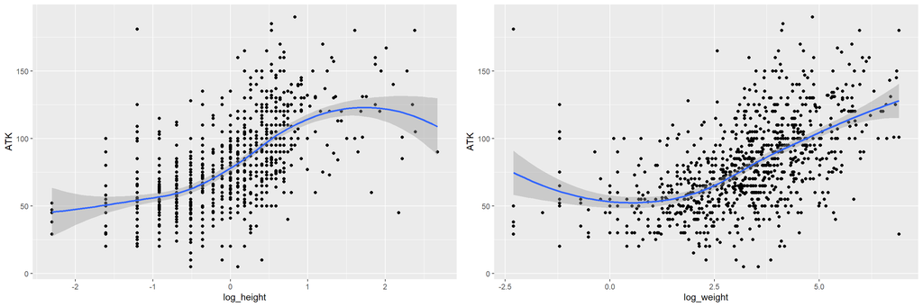

```r
library(ggpubr)

height_plot <- ggplot(data = set, mapping = aes(log_height, ATK)) +
  geom_point() +
  geom_smooth(method = "loess", formula = "y ~ x")

weight_plot <- ggplot(data = set, mapping = aes(log_weight, ATK)) +
  geom_point() +
  geom_smooth(method = "loess", formula = "y ~ x")

ggarrange(height_plot, weight_plot, ncol = 2, nrow = 1, align = "h")
```

Questi grafici dimostrano che esiste una correlazione diretta tra le altezze e i pesi sottoposti in forma logaritmica, e in questo caso l’attacco del pokemon.  
Possiamo dedurre alla fine, che esiste una correlazione logaritmica tra peso e altezza con l’attacco, la difesa ed infine, i punti salute.

## Ultima Domanda: Si può costruire un dream team Pokemon? Una squadra di 6 Pokemon che rimane relativamente impenetrabile a qualsiasi altra squadra di 6 Pokemon.

Ogni qual volta si inizia un gioco pokemon, ci si chiede quale possa essere la migliore squadra.  
Cerchiamo di usare la scienza dei dati per poter dare una risposta effettiva a questa domanda. Secondo i forum per le lotte pokemon in competitiva, per creare una squadra bisogna partire da un pokemon e analizzare le sue debolezze.  
Cercare un’altro pokemon, il quale sia immune oppure sia poco vulnerabile alle debolezze del primo, e ripetere questo fino ad avere la squadra di 6 pokemon.

```r
# Cerchiamo una combinazione di pokemon la quale abbia una ampia "copertura" dai vari attacchi
# Dobbiamo considerare le debolezze e moltiplicarle tra loro

best_candidates <- aux_set %>%
  select(name, contains("against"))

## Selezionare quelli che hanno presente almeno un zero nelle colonne delle debolezze

 best_candidates <- best_candidates %>%
  filter(rowSums(best_candidates == 0) > 0)
```

```r
## Scegliere quello che ha la somma più bassa
best_candidates <- best_candidates %>%
  rowwise() %>%
  mutate(Sum = sum(c_across("against_bug":"against_water"))) %>%
  arrange(Sum)

# Mawile
dream_team <- head(best_candidates, 1)
```

| name | against_bug | against_dark | against_dragon | against_electric | against_fairy | against_fight | against_fire | against_flying | against_ghost | against_grass | against_ground | against_ice | against_normal | against_poison | against_psychic | against_rock | against_steel | against_water | Sum |
| --- | --- | --- | --- | --- | --- | --- | --- | --- | --- | --- | --- | --- | --- | --- | --- | --- | --- | --- | --- |
| Mawile | 0.25 | 0.5 | 0 | 1 | 0.5 | 1 | 2 | 0.5 | 1 | 0.5 | 2 | 0.5 | 0.5 | 0 | 0.5 | 0.5 | 1 | 1 | 13.25 |

```r
## Da lui, cercare un altro pokemon che compensi le debolezze del primo
any(best_candidates$against_ground %in% 0)
```

```
## [1] TRUE
```

```r
new_member <- best_candidates %>%
  filter(against_ground == 0) %>%
  arrange(Sum) %>%
  head(1)

# Skarmory
dream_team <- rbind(dream_team, new_member)
```

| name | against_bug | against_dark | against_dragon | against_electric | against_fairy | against_fight | against_fire | against_flying | against_ghost | against_grass | against_ground | against_ice | against_normal | against_poison | against_psychic | against_rock | against_steel | against_water | Sum |
| --- | --- | --- | --- | --- | --- | --- | --- | --- | --- | --- | --- | --- | --- | --- | --- | --- | --- | --- | --- |
| Mawile | 0.25 | 0.5 | 0.0 | 1 | 0.5 | 1 | 2 | 0.5 | 1 | 0.50 | 2 | 0.5 | 0.5 | 0 | 0.5 | 0.5 | 1.0 | 1 | 13.25 |
| Skarmory | 0.25 | 1.0 | 0.5 | 2 | 0.5 | 1 | 2 | 0.5 | 1 | 0.25 | 0 | 1.0 | 0.5 | 0 | 0.5 | 1.0 | 0.5 | 1 | 13.50 |

```r
any(best_candidates$against_fire %in% 0)
```

```
## [1] FALSE
```

```r
any(best_candidates$against_fire %in% 0.5)
```

```
## [1] TRUE
```

```r
new_member <- best_candidates %>%
  filter(against_fire == 0.5) %>%
  arrange(Sum) %>%
  head(1)

# Marill -> Azumarill
dream_team <- rbind(dream_team, new_member)
```

| name | against_bug | against_dark | against_dragon | against_electric | against_fairy | against_fight | against_fire | against_flying | against_ghost | against_grass | against_ground | against_ice | against_normal | against_poison | against_psychic | against_rock | against_steel | against_water | Sum |
| --- | --- | --- | --- | --- | --- | --- | --- | --- | --- | --- | --- | --- | --- | --- | --- | --- | --- | --- | --- |
| Mawile | 0.25 | 0.5 | 0.0 | 1 | 0.5 | 1.0 | 2.0 | 0.5 | 1 | 0.50 | 2 | 0.5 | 0.5 | 0 | 0.5 | 0.5 | 1.0 | 1.0 | 13.25 |
| Skarmory | 0.25 | 1.0 | 0.5 | 2 | 0.5 | 1.0 | 2.0 | 0.5 | 1 | 0.25 | 0 | 1.0 | 0.5 | 0 | 0.5 | 1.0 | 0.5 | 1.0 | 13.50 |
| Marill | 0.50 | 0.5 | 0.0 | 2 | 1.0 | 0.5 | 0.5 | 1.0 | 1 | 2.00 | 1 | 0.5 | 1.0 | 2 | 1.0 | 1.0 | 1.0 | 0.5 | 17.00 |

```r
any(best_candidates$against_electric %in% 0)
```

```
## [1] TRUE
```

```r
new_member <- best_candidates %>%
  filter(against_electric == 0) %>%
  arrange(Sum) %>%
  head(1)

# Steelix
dream_team <- rbind(dream_team, new_member)
```

| name | against_bug | against_dark | against_dragon | against_electric | against_fairy | against_fight | against_fire | against_flying | against_ghost | against_grass | against_ground | against_ice | against_normal | against_poison | against_psychic | against_rock | against_steel | against_water | Sum |
| --- | --- | --- | --- | --- | --- | --- | --- | --- | --- | --- | --- | --- | --- | --- | --- | --- | --- | --- | --- |
| Mawile | 0.25 | 0.5 | 0.0 | 1 | 0.5 | 1.0 | 2.0 | 0.5 | 1 | 0.50 | 2 | 0.5 | 0.5 | 0 | 0.5 | 0.50 | 1.0 | 1.0 | 13.25 |
| Skarmory | 0.25 | 1.0 | 0.5 | 2 | 0.5 | 1.0 | 2.0 | 0.5 | 1 | 0.25 | 0 | 1.0 | 0.5 | 0 | 0.5 | 1.00 | 0.5 | 1.0 | 13.50 |
| Marill | 0.50 | 0.5 | 0.0 | 2 | 1.0 | 0.5 | 0.5 | 1.0 | 1 | 2.00 | 1 | 0.5 | 1.0 | 2 | 1.0 | 1.00 | 1.0 | 0.5 | 17.00 |
| Steelix | 0.50 | 1.0 | 0.5 | 0 | 0.5 | 2.0 | 2.0 | 0.5 | 1 | 1.00 | 2 | 1.0 | 0.5 | 0 | 0.5 | 0.25 | 0.5 | 2.0 | 15.75 |

```r
any(best_candidates$against_fight %in% 0)
```

```
## [1] TRUE
```

```r
new_member <- best_candidates %>%
  filter(against_fight == 0) %>%
  arrange(Sum) %>%
  head(1)

# Honedge --> Aegislash
dream_team <- rbind(dream_team, new_member)
```

| name | against_bug | against_dark | against_dragon | against_electric | against_fairy | against_fight | against_fire | against_flying | against_ghost | against_grass | against_ground | against_ice | against_normal | against_poison | against_psychic | against_rock | against_steel | against_water | Sum |
| --- | --- | --- | --- | --- | --- | --- | --- | --- | --- | --- | --- | --- | --- | --- | --- | --- | --- | --- | --- |
| Mawile | 0.25 | 0.5 | 0.0 | 1 | 0.5 | 1.0 | 2.0 | 0.5 | 1 | 0.50 | 2 | 0.5 | 0.5 | 0 | 0.5 | 0.50 | 1.0 | 1.0 | 13.25 |
| Skarmory | 0.25 | 1.0 | 0.5 | 2 | 0.5 | 1.0 | 2.0 | 0.5 | 1 | 0.25 | 0 | 1.0 | 0.5 | 0 | 0.5 | 1.00 | 0.5 | 1.0 | 13.50 |
| Marill | 0.50 | 0.5 | 0.0 | 2 | 1.0 | 0.5 | 0.5 | 1.0 | 1 | 2.00 | 1 | 0.5 | 1.0 | 2 | 1.0 | 1.00 | 1.0 | 0.5 | 17.00 |
| Steelix | 0.50 | 1.0 | 0.5 | 0 | 0.5 | 2.0 | 2.0 | 0.5 | 1 | 1.00 | 2 | 1.0 | 0.5 | 0 | 0.5 | 0.25 | 0.5 | 2.0 | 15.75 |
| Honedge | 0.25 | 2.0 | 0.5 | 1 | 0.5 | 0.0 | 2.0 | 0.5 | 2 | 0.50 | 2 | 0.5 | 0.0 | 0 | 0.5 | 0.50 | 0.5 | 1.0 | 14.25 |

```r
any(best_candidates$against_dark %in% 0.5)
```

```
## [1] TRUE
```

```r
# ritorna Mawile, che abbiamo già in squadra

new_member <- best_candidates %>%
  filter(against_water == 0.5) %>%
  arrange(Sum) %>%
  head(2)  ## Sarebbe Dialga, però considerare pokemon leggendari nella ricerca non è funzionale al fine di tale, pertanto usaimo il secondo che è anche uno starter

# Empoleon
dream_team <- rbind(dream_team, new_member[2, ])

final_team <- aux_set %>%
  filter(name %in% dream_team$name)  %>%
  select(name, type1, type2, hp, attack, defense, speed, sp_attack, sp_defense)

head(final_team)
```

|  | name | type1 | type2 | hp | attack | defense | speed | sp_attack | sp_defense |
| --- | --- | --- | --- | --- | --- | --- | --- | --- | --- |
| 1 | Marill | water | fairy | 70 | 20 | 50 | 40 | 20 | 50 |
| 2 | Steelix | steel | ground | 75 | 125 | 230 | 30 | 55 | 95 |
| 3 | Skarmory | steel | flying | 65 | 80 | 140 | 70 | 40 | 70 |
| 4 | Mawile | steel | fairy | 50 | 105 | 125 | 50 | 55 | 95 |
| 5 | Empoleon | water | steel | 84 | 86 | 88 | 60 | 111 | 101 |
| 6 | Honedge | steel | ghost | 45 | 80 | 100 | 28 | 35 | 37 |

Abbiam raggiunto un team ideale, ma per correttezza è giusto mettere le evoluzione finali dei pokemon

```r
# Usiam le evoluzioni finali

final_team[1,] <-aux_set %>%
  select(name, type1, type2, hp, attack, defense, speed, sp_attack, sp_defense) %>%
  filter(name == "Azumarill")

final_team[6,] <-aux_set %>%
  select(name, type1, type2, hp, attack, defense, speed, sp_attack, sp_defense) %>%
  filter(name == "Aegislash")

final_team
```

| name | type1 | type2 | hp | attack | defense | speed | sp_attack | sp_defense |
| --- | --- | --- | --- | --- | --- | --- | --- | --- |
| Azumarill | water | fairy | 100 | 50 | 80 | 50 | 60 | 80 |
| Steelix | steel | ground | 75 | 125 | 230 | 30 | 55 | 95 |
| Skarmory | steel | flying | 65 | 80 | 140 | 70 | 40 | 70 |
| Mawile | steel | fairy | 50 | 105 | 125 | 50 | 55 | 95 |
| Empoleon | water | steel | 84 | 86 | 88 | 60 | 111 | 101 |
| Aegislash | steel | ghost | 60 | 150 | 50 | 60 | 150 | 50 |

Il team finale è un buon team attaccante ed un ottimo team difensivo, ma non è il migliore. Effettivamente non esiste una squadra ottimale, esistono squadre competitive usate nei tornei ma anche quelle sono le più disparate Pertanto, la risposta alla domanda finale è che non si può creare un dream team oggettivo, dipende molto anche da quale pokemon si inizia a reclutare e soprattutto quali altri pokemon aggiungere alla squadra per compensare le vulnerabilità del primo. Alla fine, forse è propio per questo che un qualsiasi team può essere considerato “il migliore”.